# k Impact Analysis

### Functions

Load functions to run model, with most recent version

```r
source(here("Vfunctions", "V_stateUpdateT2.R")) # wrapper function, tracks epidemic in population over generations
source(here("Vfunctions", "V_DS_T2.R")) # updates state of population based on current generation
source(here("Vfunctions", "S_to_I_T2.R")) # infection simulation
source(here("Vfunctions", "effcIdGenT2.R")) # generating effective contact IDs
source(here("Vfunctions", "effcChecker.R")) # verifying effective contact IDs
source(here("Vfunctions", "reseedingT2.R")) # reseeding infection
```

```r
# function to calculate median incidence at IQR for last 100 generations
EpiStat <- function(mat) {
  if (median(mat) == 0) {
    M <- median(mat)
    iqr <- IQR(mat)
    q1 <- quantile(mat)[2]
    q3 <- quantile(mat)[4]
  } else{
    vec <- as.vector(mat[(mat != 0)])
    M <- median(vec)
    iqr <- IQR(vec)
    q1 <- quantile(vec)[2]
    q3 <- quantile(vec)[4]
  }
  sumStat <- c(M, iqr, q1, q3)
  return(sumStat)
}
```

### What Impact does the value of k have on

1. A single epidemic (Rperiod = Inf)
- Variation in magnitude of epidemic
- What proportion of epidemics take off
2. Endemicity? (Rperiod = 1)
- What is the incidence at equilibrium, what is the variation around this?
- What proportion of simulations become endemic (for given k value)?

#### A single epidemic

- Refractory Period = Infinity to simulate a single epidemic
- Investigate k values between 0.1 and Infinity
- Reseeding is off
- Is there a difference depending on whether ehterogneiety is fixed or variable?

```r
## Model Definition ##
runs <- 100
generations <- 100 # the number of generations (or timesteps) to run the model over
output <- "I_counts" # defines the output as "matrix" (full disease state and ID of units) or "counts" (number of units in S,I,R states or "I_counts" (returns only count of infected units over time)

## PARAMETERS ##

## Population Parameters ##

N <- 10000 # population size (may exxclude in favour of calculating in state_update function)
I0 <- 10
state_tracker <- c(rep("I", I0), rep("S", N - I0)) # initial disease state of units in population
population_sample <- "large" # large or small population (determines sampling strategy)

## Epidemiological Parameters ##

R_period <- Inf # the refractory period: 1 = no immunity, Inf = lifelong immunity
R0_estimate <- 3 # average number of effective contacts per unit
k_transmission <- Inf # overdispersion parameter, level of heterogeneity in effective contact potential: 0.1 = high heterogneiety, Inf = homogeneous

heterogeneity <- "fixed" # "fixed" or "variable", is unit transmission potential constant through time?
contact_list1 <- replicate(N, c(1:N), simplify = FALSE)
contact_list <- lapply(1:length(contact_list1),
                       function(x) contact_list1[[x]][-x])

## Reseeding Parameters ##
reseed <- FALSE # reseed 5 infections periodically during the first 10% of generations
reseed_threshold <- 0# threshold generation for reseeding events
reseed_frequency <- 0
introductions <- 0 # number of new cases introduced when reseeding occurs

## Vaccination Parameters ##
V_prop <- 0 # proportion to be vaccinated in each round
V_start <- 0 # start generation for vaccination
V_period <- 0 # duration of immunity from vaccination (by number of timesteps)
V_rounds <- 0 # number of rounds (-1 for starting round) of vaccination in programme
V_schedule <- 0 # how frequent is vacciantion (ie every 2 "years")
V_mode <- "random" #random, target or non_target, NB: target/non-target only possible if heterogneiety is fixed
```

#### Run Model:

```r
k_vals <- c(0.1, 0.3, 0.5, 1, Inf)
heterogeneity <- "fixed"
R_period <- Inf
reseed = FALSE
output <- "I_counts"

kEpi1_list <- list()

system.time(
  for(k in 1:length(k_vals)){

    k_transmission <- k_vals[k]

    Runs_tracker <-
      foreach (z = 1:runs, .combine = "rbind") %dopar% {
        state_update(
          state_tracker,
          N,
          population_sample,
          generations,
          output,
          R_period,
          R0_estimate,
          k_transmission,
          heterogeneity,
          contact_list,
          reseed,
          reseed_threshold,
          reseed_frequency,
          introductions,
          V_prop,
          V_start,
          V_period,
          V_rounds,
          V_schedule,
          V_mode
        )

        #runs_ <- rbind(runs_df, Runs_tracker)

      }
    kEpi1_list[[k]] <- Runs_tracker
  }
)

#kEpi1 is conditions as above with "fixed" heterogeneity
#kEpi2 is conditions as above with "variable" heterogeneity
```

### Impact of k on a single epidemic:

Magnitude of epidemic + variation:

- As k value increases, the magnitude of the epidemic in terms of cumulative incidence is not significantly affected. There is slightly greater variation in cumulative incidence for lower k values, this reflects the lower proportion of introductions which lead to epidemics for lower k values (see below)

Proportion of introductions which result in outbreaks:

• Plot 2 shows that when the value of k is lower, some introductions do not result in an epidemic (defined as causing a cumulative incidence >10% of the population). For a k value of 0.1 and 0.3 epidemic outbreaks occured in 86% and 98% of simulations. For values of k>=0.5 all simulations resulted in an epidemic.

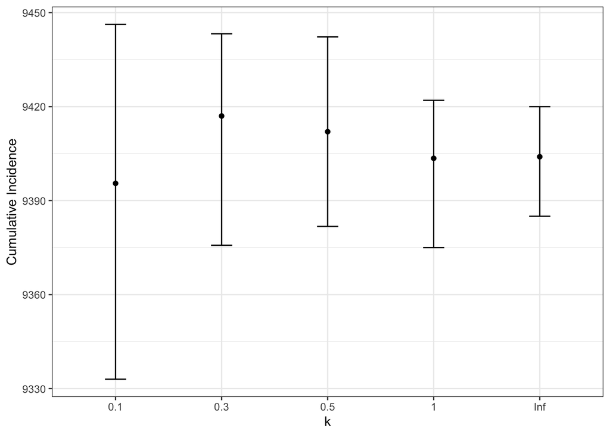

```r
# NB difference between mean epidemic when heterogeneity is fixed or variable is qualitative

load(here("data_080121/WU1/kSingleEpidemic_list.RData"))
k_vals <- c(0.1, 0.3, 0.5, 1, Inf)

#Cumualtive Incidence (median with interquartile range)

k_CumInc <- sapply(kEpi1_list, function(x)
  median(apply(x,1,sum)))
k_q1 <- sapply(kEpi1_list, function(x)
  quantile(apply(x,1,sum))[2]
  )
k_q3 <- sapply(kEpi1_list, function(x)
  quantile(apply(x,1,sum))[4]
  )

k_MedEpi <- as.data.frame(cbind("k" =k_vals,
                                "med" = k_CumInc,
                                "q1" = k_q1,
                                "q3" = k_q3))

# plot of median incidence
ggplot(data = k_MedEpi, aes(x = factor(k),y=med))+
  geom_point()+
  geom_errorbar(aes(ymin=q1, ymax=q3), width=.2)+
  xlab("k")+
  ylab("Cumulative Incidence")+
  theme_bw()
```

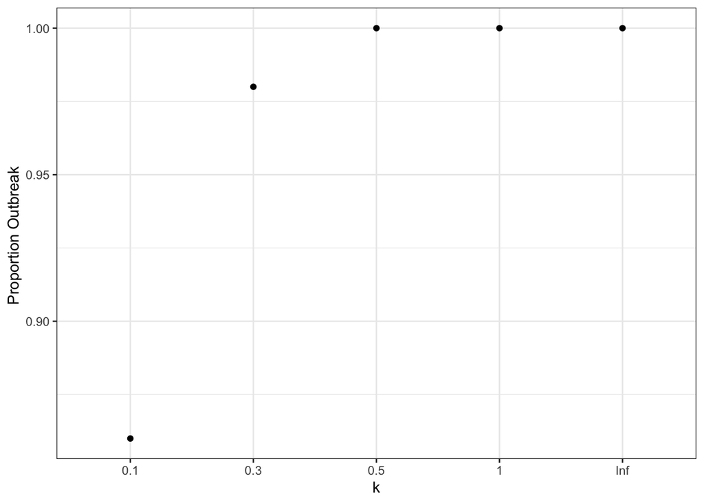

```r
#What proportion of introductions result in infection of less than 10% of the population
N <- 10000
cutoff <- 0.1*10000
runs <- 100

props <- vector()
for(l in 1:length(kEpi1_list)){
  sums <- apply(kEpi1_list[[l]],1,sum)
  prop <- length(sums[sums>cutoff]) / runs
  props <- c(props,prop)
}

k_takeoff <- as.data.frame(cbind(k_vals, props))

# plot of median incidence
ggplot(data = k_takeoff, aes(x = factor(k_vals),y=props))+
  geom_point()+
  xlab("k")+
  ylab("Proportion Outbreak ")+
  theme_bw()
```